# SIV_895_Project

----------------------------Import all the required OOTB python libraries-------------------

```python
from google.colab import drive
drive.mount('/content/drive/')
```

```python
root_path = '/content/drive/My Drive/Maverick_Data/'
train_file = root_path+'capstone_train.csv' #Path to the training file
test_file  = root_path+'capstone_test.csv'  # path to the test file
```

```python
import pandas as pd
import numpy as np
import seaborn as sns
import matplotlib
from matplotlib import pyplot as plt
from sklearn import metrics
from sklearn.metrics import classification_report, confusion_matrix,classification_report
from sklearn.metrics import accuracy_score,recall_score, precision_score, plot_confusion_matrix
import time
from tqdm import tqdm
```

```python
%%javascript
IPython.OutputArea.prototype._should_scroll = function(lines) {
    return false;
}
```

Function: read_data_file  
Input: training file path, test file path  
Output : dataframes for training features, training labels, testing features, testing lables

```python
def read_data_file(train_file,test_file):
    df_train = pd.read_csv(train_file) #reading training datafile
    df_test  = pd.read_csv(test_file)   #reading test datafile
    train_x  = df_train[df_train.columns[0:12]] #training features
    train_y  = df_train[df_train.columns[-1]] #traininig labels
    test_x   = df_test[df_test.columns[0:12]] #training features
    test_y   = df_test[df_test.columns[-1]] #traininig labels

    print('Shape of traning data :',train_x.shape,train_y.shape)
    print('Shape of testing data :',test_x.shape,test_y.shape)
    return train_x,train_y,test_x,test_y

train_x,train_y,test_x,test_y = read_data_file(train_file,test_file)
```

```
Shape of traning data : (464809, 12) (464809,)
Shape of testing data : (116203, 12) (116203,)
```

```python
#First five rows ofthe training features
train_x.head()
```

|  | Heigh_From_Sea_Level | Aspect | Slope | Distance_To_Water_Source | Standing_Distance_To_Water_Source | Distance_To_Road | Shadow_In_Morning | Shadow_In_Midday | Shadow_In_Evening | Distance_To_Fire | Turf | Neighbourhood_Type |
| --- | --- | --- | --- | --- | --- | --- | --- | --- | --- | --- | --- | --- |
| 0 | 2984 | 87 | 10 | 234 | 62 | 3700 | 235 | 224.0 | 119 | 2751 | 29 | 1 |
| 1 | 3021 | 283 | 31 | 630 | 372 | 2155 | 122 | 224.0 | 234 | 1519 | 13 | 3 |
| 2 | 3357 | 164 | 14 | 618 | 151 | 1410 | 232 | 244.0 | 140 | 1866 | 32 | 3 |
| 3 | 2787 | 272 | 16 | 150 | 40 | 2024 | 176 | 243.0 | 206 | 957 | 31 | 3 |
| 4 | 3011 | 135 | 2 | 576 | 95 | 5550 | 222 | 238.0 | 151 | 1524 | 29 | 1 |

## Performance Measurement :-

```python
def cal_accuracy(v_test_x,v_test_y,v_model):
    #make predictions using the given model
    y_pred = v_model.predict(v_test_x)
    # how did our model perform?
    count_misclassified = (v_test_y != y_pred).sum()
    print('Total samples : {}' .format(len(v_test_x)))
    print('Misclassified samples: {}'.format(count_misclassified))
    print('Accuracy: {:.2f} %'.format(accuracy_score(v_test_y, y_pred)))
    print('\n')
    print('Classification Report :')
    print('\n')
    print(classification_report(v_test_y,y_pred,labels=np.unique(v_test_y)))
    print('Confusion Matrix :')
    print('\n')
    print(plot_confusion_matrix(v_model,v_test_x,v_test_y,cmap=plt.cm.Blues))
```

**Exploratory Data Analysis:-** Exploratory Data Analysis is an approach to analyzing data sets by summarizing their main characteristics with visualizations. The EDA process is a crucial step prior to building a model in order to unravel various insights that later become important in developing a robust algorithmic model.

```python
# Describe function with include=’all’ argument it displays the descriptive statistics for all the column
print(train_x.describe(include='all'))
#number of unique classe = 7, Therefore, we need multi-class classifier
print('\n')
print('The Target Classes :')
print(train_y.unique())
print('\n')
print('Frequncy count of each target class :')
uniqueValues, occurCount = np.unique(train_y, return_counts=True)
for i in zip(uniqueValues,occurCount):
    print(i)
```

```
       Heigh_From_Sea_Level         Aspect  ...           Turf  Neighbourhood_Type
count         464809.000000  464809.000000  ...  464809.000000       464809.000000
mean            2959.483063     155.661235  ...      24.370455            2.113563
std              279.781777     111.919973  ...       9.478907            1.061051
min             1859.000000       0.000000  ...       1.000000            1.000000
25%             2809.000000      58.000000  ...      20.000000            1.000000
50%             2996.000000     127.000000  ...      29.000000            2.000000
75%             3163.000000     261.000000  ...      31.000000            3.000000
max             3858.000000     360.000000  ...      40.000000            4.000000

[8 rows x 12 columns]


The Target Classes :
['Assassin vine' 'Ascomoid' 'Basidirond' 'Kelpie' 'Myconid:'
 'Hangman tree' 'Dark tree']


Frequncy count of each target class :
('Ascomoid', 169487)
('Assassin vine', 226705)
('Basidirond', 28488)
('Dark tree', 2184)
('Hangman tree', 7598)
('Kelpie', 13931)
('Myconid:', 16416)
```

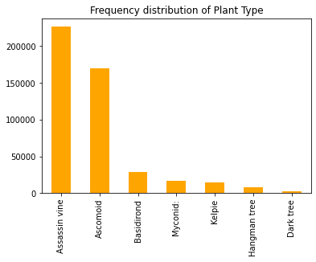

```python
 #x-axis showing the specific Plant Type and the y-axis the measured value.
train_y.value_counts().plot.bar(title='Frequency distribution of Plant Type', color='orange')
```

1. The univariate distribution plot of the numerical columns which contains the histograms and the estimated PDF.

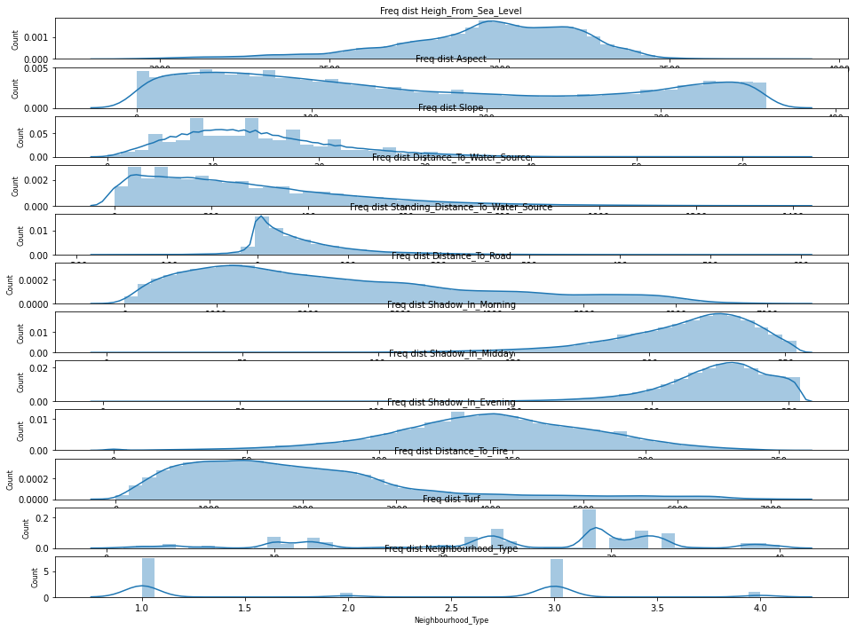

```python
col_names = ['Heigh_From_Sea_Level','Aspect', 'Slope', 'Distance_To_Water_Source', 'Standing_Distance_To_Water_Source', 'Distance_To_Road','Shadow_In_Morning','Shadow_In_Midday','Shadow_In_Evening','Distance_To_Fire','Turf','Neighbourhood_Type']
fig, ax = plt.subplots(len(col_names), figsize=(16,12))

for i, col_val in enumerate(col_names):

    sns.distplot(train_x[col_val], hist=True, ax=ax[i])
    ax[i].set_title('Freq dist '+col_val, fontsize=10)
    ax[i].set_xlabel(col_val, fontsize=8)
    ax[i].set_ylabel('Count', fontsize=8)

plt.show()
```

1. Bivariate distribution plots help us to study the relationship between two variables by analyzing the scatter plot

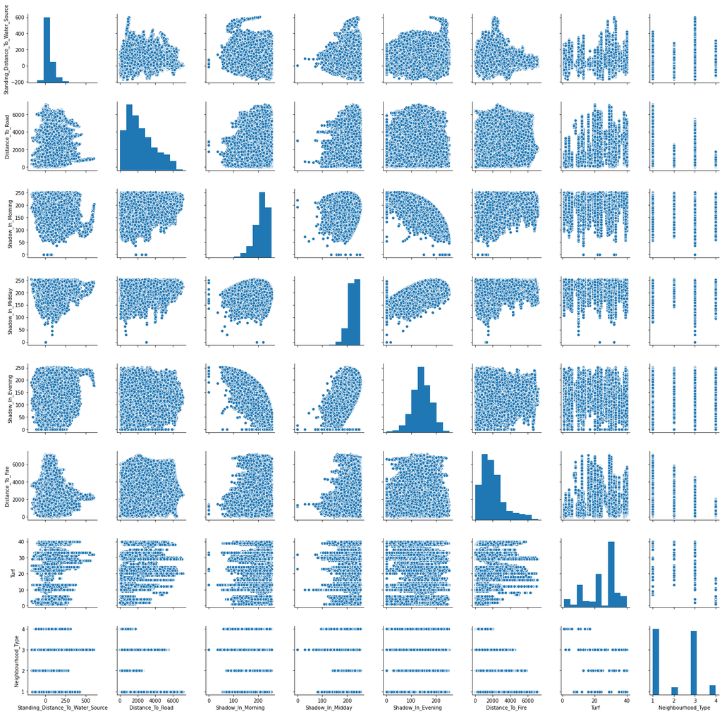

```python
plant_data = train_x
plant_data= plant_data.drop([
      'Heigh_From_Sea_Level','Aspect', 'Slope', 'Distance_To_Water_Source'], axis=1)
sns.pairplot(plant_data)
```

**Correlation matrix:-**

It is a table showing the value of the correlation coefficien (how strong a relationship is between two variables ) between sets of variables. Each attribute of the dataset is compared with the other attributes to find out the correlation coefficient.The pairs which are highly correlated represent the same variance of the dataset thus we can further analyze them to understand which attribute among the pairs are most significant for building the model.

Correlation value lies between -1 to +1. Highly correlated variables will have correlation value close to +1 and less correlated variables will have correlation value close to -1.

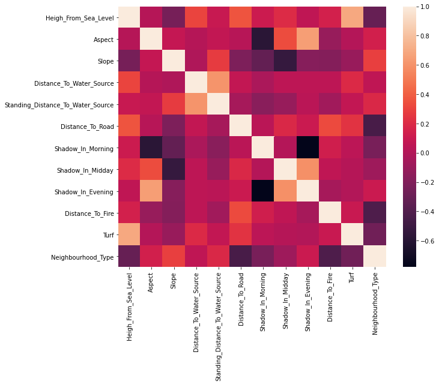

```python
f, ax = plt.subplots(figsize=(10, 8))
corr  = train_x.corr()
sns.heatmap(corr,
            xticklabels=corr.columns.values,
            yticklabels=corr.columns.values)
```

## Data Pre-Processing

**Missing Values :-** </br> Missing values in the dataset refer to those fields which are empty or no values assigned to them.

```python
def pre_processing_data(X):
#return true if there is any missing value in the data set
    if X.isnull().values.any() == True:
        print('There are some missing values in the training dataset ')
        print('The number of missing values in the training dataset :',X.isnull().sum())
        #The fillna function of pandas to replace 'na' values with the value 0 and inplace=True
        X.fillna(0, inplace=True)
        print('Missing values have been replaced with 0')
        print('Missing values in the dataset anymore? ',X.isnull().values.any())
        print('\n')
    else:
        print('No missing values in the data set!')
        print('\n')
    return X

#Missing values are replaced with 0, if any present in the dataset
train_x = pre_processing_data(train_x)
test_x = pre_processing_data(test_x)
```

```
There are some missing values in the training dataset
The number of missing values in the training dataset : Heigh_From_Sea_Level                     0
Aspect                                   0
Slope                                    0
Distance_To_Water_Source                 0
Standing_Distance_To_Water_Source        0
Distance_To_Road                         0
Shadow_In_Morning                        0
Shadow_In_Midday                     93033
Shadow_In_Evening                        0
Distance_To_Fire                         0
Turf                                     0
Neighbourhood_Type                       0
dtype: int64
Missing values have been replaced with 0
Missing values in the dataset anymore?  False


There are some missing values in the training dataset
The number of missing values in the training dataset : Heigh_From_Sea_Level                     0
Aspect                                   0
Slope                                    0
Distance_To_Water_Source                 0
Standing_Distance_To_Water_Source        0
Distance_To_Road                         0
Shadow_In_Morning                        0
Shadow_In_Midday                     23079
Shadow_In_Evening                        0
Distance_To_Fire                         0
Turf                                     0
Neighbourhood_Type                       0
dtype: int64
Missing values have been replaced with 0
Missing values in the dataset anymore?  False
```

# Random Forest Classifier

It is an ensemble tree-based learning algorithm. The Random Forest Classifier is a set of decision trees from randomly selected subset of training set. It aggregates the votes from different decision trees to decide the final class of the test object.

```
Time taken to train the Model in minutes : 2.4530380686124165
Total samples : 116203
Misclassified samples: 4429
Accuracy: 0.96 %


Classification Report :


               precision    recall  f1-score   support

     Ascomoid       0.97      0.96      0.96     42353
Assassin vine       0.96      0.98      0.97     56596
   Basidirond       0.95      0.97      0.96      7266
    Dark tree       0.92      0.87      0.89       563
 Hangman tree       0.94      0.81      0.87      1895
       Kelpie       0.94      0.91      0.93      3436
     Myconid:       0.98      0.95      0.97      4094

     accuracy                           0.96    116203
    macro avg       0.95      0.92      0.93    116203
 weighted avg       0.96      0.96      0.96    116203

Confusion Matrix :


<sklearn.metrics._plot.confusion_matrix.ConfusionMatrixDisplay object at 0x7fc336e44e10>
```

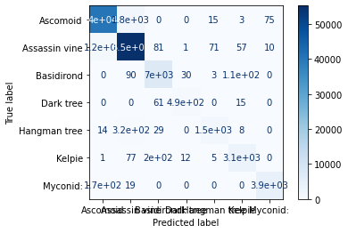

```python
from sklearn.ensemble import RandomForestClassifier
clf_rf = RandomForestClassifier()
t0 = time.time()
clf_rf.fit(train_x, train_y)
print('Time taken to train the Model in minutes :', (time.time() - t0)/60)
cal_accuracy(test_x,test_y,clf_rf)
```

```
Time taken to train the Model in minutes : 2.597380006313324
Total samples : 116203
Misclassified samples: 112109
Accuracy: 0.04 %


Classification Report :
```

```
               precision    recall  f1-score   support

     Ascomoid       0.00      0.00      0.00     42353
Assassin vine       0.00      0.00      0.00     56596
   Basidirond       0.00      0.00      0.00      7266
    Dark tree       0.00      0.00      0.00       563
 Hangman tree       0.00      0.00      0.00      1895
       Kelpie       0.00      0.00      0.00      3436
     Myconid:       0.04      1.00      0.07      4094

     accuracy                           0.04    116203
    macro avg       0.01      0.14      0.01    116203
 weighted avg       0.00      0.04      0.00    116203

Confusion Matrix :


<sklearn.metrics._plot.confusion_matrix.ConfusionMatrixDisplay object at 0x7fc336d70048>
```

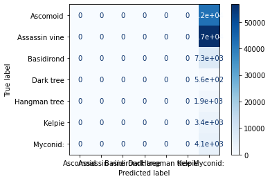

```python
from sklearn.preprocessing import StandardScaler
scaler = StandardScaler()
# Fit on training set only.
scaler.fit(train_x)
# Apply transform to both the training set and the test set.
scaler_train_x = scaler.transform(train_x)
scaler_test_x = scaler.transform(test_x)
clf_scal = RandomForestClassifier()
t0 = time.time()
clf_scal.fit(scaler_train_x, train_y)
print('Time taken to train the Model in minutes :', (time.time() - t0)/60)
cal_accuracy(test_x,test_y,clf_scal)
```

## Logistic Regression :-

Logistic regression is a statistical model that in its basic form uses a logistic function to model a binary dependent variable.Outputs with more than two values are modeled by multinomial logistic regression.

```
Time taken to train the Model in minutes : 5.7295293291409815


Total samples : 116203
Misclassified samples: 36647
Accuracy: 0.68 %


Classification Report :
```

```
               precision    recall  f1-score   support

     Ascomoid       0.66      0.68      0.67     42353
Assassin vine       0.71      0.79      0.75     56596
   Basidirond       0.63      0.78      0.69      7266
    Dark tree       0.63      0.05      0.09       563
 Hangman tree       0.00      0.00      0.00      1895
       Kelpie       0.37      0.05      0.09      3436
     Myconid:       0.47      0.04      0.07      4094

     accuracy                           0.68    116203
    macro avg       0.50      0.34      0.34    116203
 weighted avg       0.66      0.68      0.66    116203

Confusion Matrix :


<sklearn.metrics._plot.confusion_matrix.ConfusionMatrixDisplay object at 0x7fc33a4ca6a0>
```

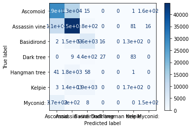

```python
from sklearn.linear_model import LogisticRegression
t0 = time.time()
clf_log_reg = LogisticRegression(max_iter=1000 ).fit(train_x, train_y)
print('Time taken to train the Model in minutes :', (time.time() - t0)/60)
print('\n')
cal_accuracy(test_x,test_y,clf_log_reg)
```

## Normalization/ Standardization :-

**Normalization** typically means rescales the values into a range of [0,1].  
**Standardization** typically means rescales data to have a mean of 0 and a standard deviation of 1 (unit variance).

```python
#Normalize the data
from sklearn import preprocessing
normalized_train_x = preprocessing.normalize(train_x)
normalized_test_x = preprocessing.normalize(test_x)
```

```
Time taken to train the Model in minutes : 4.982972280184428
Total samples : 116203
Misclassified samples: 41673
Accuracy: 0.64 %


Classification Report :
```

```
               precision    recall  f1-score   support

     Ascomoid       0.65      0.58      0.61     42353
Assassin vine       0.64      0.82      0.72     56596
   Basidirond       0.63      0.47      0.54      7266
    Dark tree       0.00      0.00      0.00       563
 Hangman tree       0.00      0.00      0.00      1895
       Kelpie       0.00      0.00      0.00      3436
     Myconid:       0.00      0.00      0.00      4094

     accuracy                           0.64    116203
    macro avg       0.27      0.27      0.27    116203
 weighted avg       0.59      0.64      0.61    116203

Confusion Matrix :


<sklearn.metrics._plot.confusion_matrix.ConfusionMatrixDisplay object at 0x7fc34ddc2160>
```

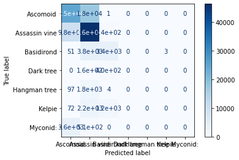

```python
t0 = time.time()
clf_lin_reg_norm = LogisticRegression(max_iter=1000).fit(normalized_train_x, train_y)
print('Time taken to train the Model in minutes :', (time.time() - t0)/60)
cal_accuracy(normalized_test_x,test_y,clf_lin_reg_norm)
```

```
Time taken to train the Model in minutes : 0.5971746007601421
Total samples : 116203
Misclassified samples: 33792
Accuracy: 0.71 %


Classification Report :
```

```
               precision    recall  f1-score   support

     Ascomoid       0.69      0.69      0.69     42353
Assassin vine       0.74      0.79      0.76     56596
   Basidirond       0.65      0.80      0.72      7266
    Dark tree       0.63      0.28      0.39       563
 Hangman tree       0.00      0.00      0.00      1895
       Kelpie       0.39      0.15      0.22      3436
     Myconid:       0.72      0.48      0.57      4094

     accuracy                           0.71    116203
    macro avg       0.55      0.46      0.48    116203
 weighted avg       0.69      0.71      0.70    116203

Confusion Matrix :


<sklearn.metrics._plot.confusion_matrix.ConfusionMatrixDisplay object at 0x7fc336a19b00>
```

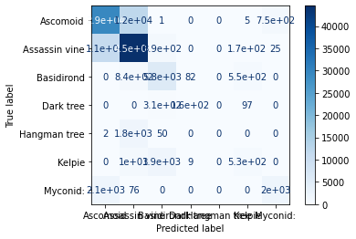

```python
#using scaled data
Log_reg_sca = LogisticRegression(solver = 'lbfgs')
t0 = time.time()
Log_reg_sca.fit(scaler_train_x, train_y)
print('Time taken to train the Model in minutes :', (time.time() - t0)/60)
cal_accuracy(scaler_test_x,test_y,Log_reg_sca)
```

```
Time taken to train the Model in minutes : 3.0544974327087404
Total samples : 116203
Misclassified samples: 33744
Accuracy: 0.71 %


Classification Report :
```

```
               precision    recall  f1-score   support

     Ascomoid       0.69      0.69      0.69     42353
Assassin vine       0.74      0.79      0.76     56596
   Basidirond       0.65      0.80      0.72      7266
    Dark tree       0.65      0.33      0.44       563
 Hangman tree       0.00      0.00      0.00      1895
       Kelpie       0.39      0.16      0.23      3436
     Myconid:       0.72      0.48      0.58      4094

     accuracy                           0.71    116203
    macro avg       0.55      0.46      0.49    116203
 weighted avg       0.69      0.71      0.70    116203

Confusion Matrix :


<sklearn.metrics._plot.confusion_matrix.ConfusionMatrixDisplay object at 0x7fc3369032e8>
```

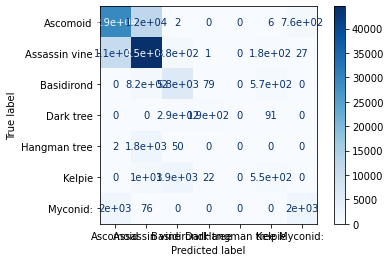

```python
from sklearn.preprocessing import RobustScaler
transformer = RobustScaler().fit(train_x)
train_x_robust = transformer.transform(train_x)
test_x_robust = transformer.transform(test_x)
t0 = time.time()
clf_robust= LogisticRegression(max_iter=1000).fit(train_x_robust, train_y)
print('Time taken to train the Model in minutes :', (time.time() - t0)/60)
cal_accuracy(test_x_robust,test_y,clf_robust)
```

# SVM

Support vector machines (SVMs) are a set of supervised learning methods used for classification, regression and outliers detection.

The advantages of support vector machines are:  
Effective in high dimensional spaces. Still effective in cases where number of dimensions is greater than the number of samples. Uses a subset of training points in the decision function (called support vectors), so it is also memory efficient.  
Versatile: different Kernel functions can be specified for the decision function. Common kernels are provided, but it is also possible to specify custom kernels.

```
Time taken to train the Model in minutes : 4.997809398174286
Total samples : 116203
Misclassified samples: 38918
Accuracy: 0.67 %


Classification Report :
```

```
               precision    recall  f1-score   support

     Ascomoid       0.64      0.67      0.66     42353
Assassin vine       0.68      0.78      0.73     56596
   Basidirond       0.65      0.67      0.66      7266
    Dark tree       0.00      0.00      0.00       563
 Hangman tree       0.00      0.00      0.00      1895
       Kelpie       0.00      0.00      0.00      3436
     Myconid:       0.50      0.00      0.00      4094

     accuracy                           0.67    116203
    macro avg       0.35      0.30      0.29    116203
 weighted avg       0.62      0.67      0.63    116203

Confusion Matrix :


<sklearn.metrics._plot.confusion_matrix.ConfusionMatrixDisplay object at 0x7fc3369ce6a0>
```

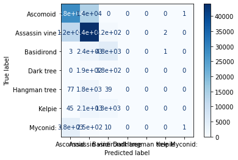

```python
from sklearn.svm import LinearSVC
#one-vs-the-rest
from sklearn.feature_selection import SelectFromModel
t0 = time.time()
lsvc = LinearSVC(C=0.01, penalty="l1", dual=False).fit(train_x, train_y)
print('Time taken to train the Model in minutes :', (time.time() - t0)/60)
cal_accuracy(test_x,test_y,lsvc)
```

**One v/s Rest Linear Classifier**

```python
from sklearn.multiclass import OneVsRestClassifier
from sklearn.svm import LinearSVC
t0 = time.time()
onevsrest_class = OneVsRestClassifier(LinearSVC(random_state=0)).fit(train_x, train_y)
print('Time taken to train the Logistic Regression Model in minutes :', (time.time() - t0)/60)
cal_accuracy(test_x,test_y,onevsrest_class)
```

[output not shown]

# Hyper Parameters Tuning

```python
from sklearn.svm import SVC
from sklearn.model_selection import GridSearchCV
from sklearn.metrics import roc_auc_score

clf = SVC(kernel='rbf')
grid_values = {'gamma': [0.001, 0.01, 0.1, 1]}

# default metric to optimize over grid parameters: accuracy
grid_clf_acc = GridSearchCV(clf, param_grid = grid_values, cv=3)
grid_clf_acc.fit(train_x[0:5000],train_y[0:5000])
y_decision_fn_scores_acc = grid_clf_acc.decision_function(test_x)

print('Grid best parameter (max. accuracy): ', grid_clf_acc.best_params_)
print('Grid best score (accuracy): ', grid_clf_acc.best_score_)
```

```
Grid best parameter (max. accuracy):  {'gamma': 0.001}
Grid best score (accuracy):  0.48859999908781754
```

```
Time taken to train the Model in minutes : 4.6893228928248085
Total samples : 116203
Misclassified samples: 39073
Accuracy: 0.66 %


Classification Report :
```

```
               precision    recall  f1-score   support

     Ascomoid       0.64      0.67      0.66     42353
Assassin vine       0.68      0.78      0.73     56596
   Basidirond       0.65      0.66      0.65      7266
    Dark tree       0.00      0.00      0.00       563
 Hangman tree       0.00      0.00      0.00      1895
       Kelpie       0.00      0.00      0.00      3436
     Myconid:       0.00      0.00      0.00      4094

     accuracy                           0.66    116203
    macro avg       0.28      0.30      0.29    116203
 weighted avg       0.61      0.66      0.63    116203

Confusion Matrix :


<sklearn.metrics._plot.confusion_matrix.ConfusionMatrixDisplay object at 0x7fc33692f5f8>
```

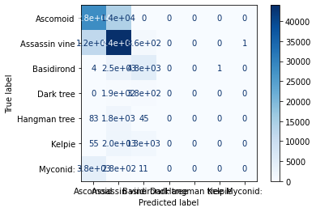

```python
from sklearn.svm import LinearSVC
#one-vs-the-rest
from sklearn.feature_selection import SelectFromModel
t0 = time.time()
lsvc = LinearSVC(C=0.001, penalty="l1", dual=False).fit(train_x, train_y)
print('Time taken to train the Model in minutes :', (time.time() - t0)/60)
cal_accuracy(test_x,test_y,lsvc)
```

# K-Nearest Neighbors

In k-NN classification, the output is a class membership. An object is classified by a plurality vote of its neighbors, with the object being assigned to the class most common among its k nearest neighbors (k is a positive integer, typically small). If k = 1, then the object is simply assigned to the class of that single nearest neighbor.  
In k-NN regression, the output is the property value for the object. This value is the average of the values of k nearest neighbors.

Finding the best number of neighbors for knn to avoid the over fitting

```python
n_neighbors_list = [1,3,5,7,10]
for k in n_neighbors_list:
    knn = KNeighborsClassifier(n_neighbors = k).fit(train_x, train_y)
    print(knn.score(test_x,test_y))
```

```
0.9565932032735815
0.9557584571826889
0.9526604304536027
0.9475917144996256
0.9388570002495633
```

```
Time taken to train the Model in minutes : 0.043256866931915286
Total samples : 116203
Misclassified samples: 5141
Accuracy: 0.96 %


Classification Report :


               precision    recall  f1-score   support

     Ascomoid       0.96      0.96      0.96     42353
Assassin vine       0.96      0.96      0.96     56596
   Basidirond       0.95      0.96      0.95      7266
    Dark tree       0.90      0.78      0.84       563
 Hangman tree       0.89      0.86      0.88      1895
       Kelpie       0.91      0.90      0.91      3436
     Myconid:       0.96      0.95      0.95      4094

     accuracy                           0.96    116203
    macro avg       0.93      0.91      0.92    116203
 weighted avg       0.96      0.96      0.96    116203

Confusion Matrix :


<sklearn.metrics._plot.confusion_matrix.ConfusionMatrixDisplay object at 0x7fc336bd09b0>
```

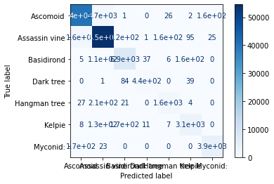

```python
from sklearn.neighbors import KNeighborsClassifier
t0 = time.time()
knn = KNeighborsClassifier(n_neighbors = 3).fit(train_x, train_y)
print('Time taken to train the Model in minutes :', (time.time() - t0)/60)
cal_accuracy(test_x,test_y,knn)
```